# FoodHub_Nikita

```python
# importing necessary libraries
import pandas as pd
import numpy as np
import seaborn as sns
import matplotlib.pyplot as plt
```

```python
# Importing the dataset
df = pd.read_csv('foodhub_order.csv')
```

```python
# Displaying the top 5 rows of the dataset
df.head()
```

|  | order_id | customer_id | restaurant_name | cuisine_type | cost_of_the_order | day_of_the_week | rating | food_preparation_time | delivery_time |
| --- | --- | --- | --- | --- | --- | --- | --- | --- | --- |
| 0 | 1477147 | 337525 | Hangawi | Korean | 30.75 | Weekend | Not given | 25 | 20 |
| 1 | 1477685 | 358141 | Blue Ribbon Sushi Izakaya | Japanese | 12.08 | Weekend | Not given | 25 | 23 |
| 2 | 1477070 | 66393 | Cafe Habana | Mexican | 12.23 | Weekday | 5 | 23 | 28 |
| 3 | 1477334 | 106968 | Blue Ribbon Fried Chicken | American | 29.20 | Weekend | 3 | 25 | 15 |
| 4 | 1478249 | 76942 | Dirty Bird to Go | American | 11.59 | Weekday | 4 | 25 | 24 |

```python
#Displaying the bottom 5 rows of the dataset
df.tail()
```

|  | order_id | customer_id | restaurant_name | cuisine_type | cost_of_the_order | day_of_the_week | rating | food_preparation_time | delivery_time |
| --- | --- | --- | --- | --- | --- | --- | --- | --- | --- |
| 1893 | 1476701 | 292602 | Chipotle Mexican Grill $1.99 Delivery | Mexican | 22.31 | Weekend | 5 | 31 | 17 |
| 1894 | 1477421 | 397537 | The Smile | American | 12.18 | Weekend | 5 | 31 | 19 |
| 1895 | 1477819 | 35309 | Blue Ribbon Sushi | Japanese | 25.22 | Weekday | Not given | 31 | 24 |
| 1896 | 1477513 | 64151 | Jack's Wife Freda | Mediterranean | 12.18 | Weekday | 5 | 23 | 31 |
| 1897 | 1478056 | 120353 | Blue Ribbon Sushi | Japanese | 19.45 | Weekend | Not given | 28 | 24 |

```python
#Relacing the 'Not given' values in rating with Nan
df['rating'] = df['rating'].replace(['Not given'],np.nan)
```

```python
#Checking if the 'Not given' values in rating are replaced with Nan
df.tail()
```

|  | order_id | customer_id | restaurant_name | cuisine_type | cost_of_the_order | day_of_the_week | rating | food_preparation_time | delivery_time |
| --- | --- | --- | --- | --- | --- | --- | --- | --- | --- |
| 1893 | 1476701 | 292602 | Chipotle Mexican Grill $1.99 Delivery | Mexican | 22.31 | Weekend | 5 | 31 | 17 |
| 1894 | 1477421 | 397537 | The Smile | American | 12.18 | Weekend | 5 | 31 | 19 |
| 1895 | 1477819 | 35309 | Blue Ribbon Sushi | Japanese | 25.22 | Weekday | NaN | 31 | 24 |
| 1896 | 1477513 | 64151 | Jack's Wife Freda | Mediterranean | 12.18 | Weekday | 5 | 23 | 31 |
| 1897 | 1478056 | 120353 | Blue Ribbon Sushi | Japanese | 19.45 | Weekend | NaN | 28 | 24 |

Question 1: How many rows and columns are present in the data? [0.5 mark]

```python
# Printing the rows and columns in the dataset
print('The number of rows are',df.shape[0],'and the number of columns are',df.shape[1])
```

```
The number of rows are 1898 and the number of columns are 9
```

Question 2: What are the datatypes of the different columns in the dataset? (The info() function can be used) [0.5 mark]

```python
#Printing the datatypes of each column
df.info()
```

```
<class 'pandas.core.frame.DataFrame'>
RangeIndex: 1898 entries, 0 to 1897
Data columns (total 9 columns):
 #   Column                 Non-Null Count  Dtype
---  ------                 --------------  -----
 0   order_id               1898 non-null   int64
 1   customer_id            1898 non-null   int64
 2   restaurant_name        1898 non-null   object
 3   cuisine_type           1898 non-null   object
 4   cost_of_the_order      1898 non-null   float64
 5   day_of_the_week        1898 non-null   object
 6   rating                 1162 non-null   object
 7   food_preparation_time  1898 non-null   int64
 8   delivery_time          1898 non-null   int64
dtypes: float64(1), int64(4), object(4)
memory usage: 133.6+ KB
```

**Observations:** There are 5 numerical columns in the data. They are order_id, customer_id, cost_of_the_order, food_preparation_time and delivery_time

There are 3 categorical columns in the data They are restaurant_name, cuisine_type and day_of_the_week

**Question 3:** Are there any missing values in the data? If yes, treat them using an appropriate method. [1 mark]

```python
df.isnull()
```

|  | order_id | customer_id | restaurant_name | cuisine_type | cost_of_the_order | day_of_the_week | rating | food_preparation_time | delivery_time |
| --- | --- | --- | --- | --- | --- | --- | --- | --- | --- |
| 0 | False | False | False | False | False | False | True | False | False |
| 1 | False | False | False | False | False | False | True | False | False |
| 2 | False | False | False | False | False | False | False | False | False |
| 3 | False | False | False | False | False | False | False | False | False |
| 4 | False | False | False | False | False | False | False | False | False |
| ... | ... | ... | ... | ... | ... | ... | ... | ... | ... |
| 1893 | False | False | False | False | False | False | False | False | False |
| 1894 | False | False | False | False | False | False | False | False | False |
| 1895 | False | False | False | False | False | False | True | False | False |
| 1896 | False | False | False | False | False | False | False | False | False |
| 1897 | False | False | False | False | False | False | True | False | False |

1898 rows × 9 columns

```python
df.isnull().sum()
```

|  | 0 |
| --- | --- |
| order_id | 0 |
| customer_id | 0 |
| restaurant_name | 0 |
| cuisine_type | 0 |
| cost_of_the_order | 0 |
| day_of_the_week | 0 |
| rating | 736 |
| food_preparation_time | 0 |
| delivery_time | 0 |

**dtype:** int64

**Observation:** 'Rating' is the only column that has missing values. It has 736 missing values

**Question 4:** Check the statistical summary of the data. What is the minimum, average, and maximum time it takes for food to be prepared once an order is placed? [2 marks]

```python
df['food_preparation_time'].describe().T
```

|  | food_preparation_time |
| --- | --- |
| count | 1898.000000 |
| mean | 27.371970 |
| std | 4.632481 |
| min | 20.000000 |
| 25% | 23.000000 |
| 50% | 27.000000 |
| 75% | 31.000000 |
| max | 35.000000 |

**dtype:** float64

**Observations:**

1. Min food preparation time is 20 mins
2. Max food preparation time is 35 mins
3. Half of the orders take 27 mins to be preapared while 75% of the orders are prepared by 31 mins

**Question 5:** How many orders are not rated? [1 mark]

```python
orders_not_rated = df[df['rating'].isna()]['order_id'].nunique()
print('The number of orders that are not rated are:',orders_not_rated)
```

```
The number of orders that are not rated are: 736
```

**Exploratory Data Analysis (EDA)**

**Univariate Analysis**

**Question 6:** Explore all the variables and provide observations on their distributions. (Generally, histograms, boxplots, countplots, etc. are used for univariate exploration.) [9 marks]

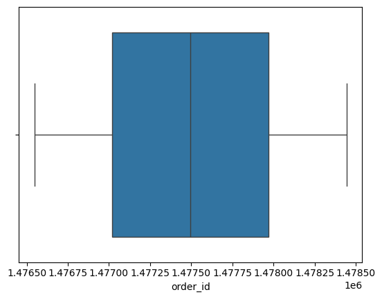

```python
sns.boxplot(data=df,x='order_id')
plt.show()
```

**Observations:**

1. There are no outliers

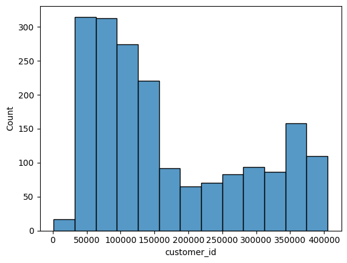

```python
sns.histplot(data=df,x='customer_id')
plt.show()
```

**Observations:**

1. Customer_id starts from 1 to more than 4 lakh
2. Most number of customer_ids are around 50000
3. 2nd most number of customer_ids are around 55000 and 99500

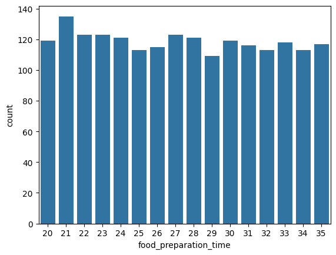

```python
sns.countplot(data=df,x='food_preparation_time')
plt.show()
```

**Observations:**

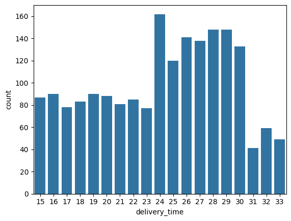

```python
sns.countplot(data=df,x='delivery_time')
plt.show()
```

**Observation:** 1) The highest number of orders which is around 160 orders take 24 mins to be delivered 2) The least number of orders which is around 40 orders take 31 mins to be delivered 3) Minimum delivery time is 15 mins 4) Maximum delivery time is 33 mins

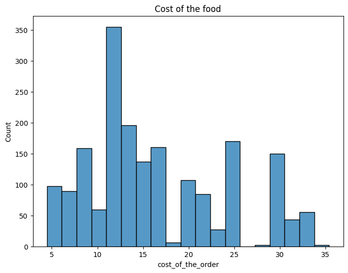

```python
plt.figure(figsize=(8,6))
sns.histplot(data=df, x="cost_of_the_order")
plt.title("Cost of the food")
plt.show()
```

**Observations:**

1. About 350 orders cost \$12
2. Most of the orders cost less than \$20
3. Min cost of the orders is around \$4.5 and max cost of the orders is about \$35

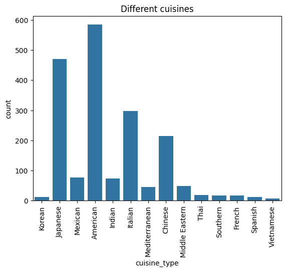

```python
sns.countplot(data=df, x="cuisine_type")
plt.title("Different cuisines")
plt.xticks(rotation=90)
plt.show()
```

**Observations:**

1. American cuisine is the most popular cuisine
2. Japanese cusine is the 2nd most ordered cuisine
3. Vietnamese cuisine is the least popular cuisine to be ordered
4. Number of orders are nearly same for both Indian and Mexican cuisines
5. Number of orders are nearly same for Thai, Southern and French

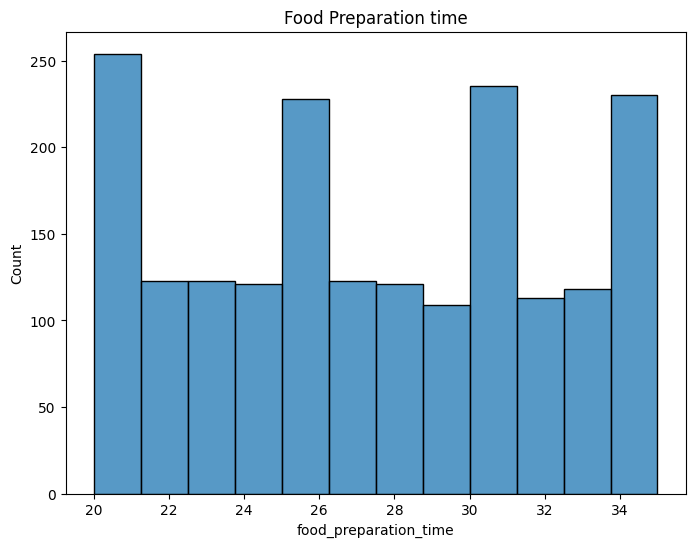

```python
plt.figure(figsize=(8,6))
sns.histplot(data=df, x="food_preparation_time")
plt.title("Food Preparation time")
plt.show()
```

**Observations:** 1) Min time taken to prepare food is 20 mins 2) 250 orders take about 21 mins to prepare food 3) 230 orders take about 31 mins to prepare food

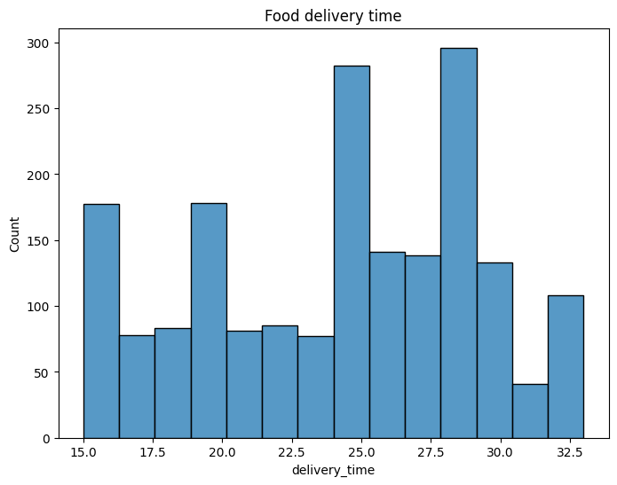

```python
plt.figure(figsize=(8,6))
sns.histplot(data=df, x="delivery_time")
plt.title("Food delivery time")
plt.show()
```

**Observations:** 1) About 290 orders take about 29 mins to be delivered 2) About 40 orders take about 31 mins to be delivered

**Question 7:** Which are the top 5 restaurants in terms of the number of orders received? [1 mark]

```python
#Printing all the restaurant names
df['restaurant_name'].unique()
```

```
array(['Hangawi', 'Blue Ribbon Sushi Izakaya', 'Cafe Habana',
       'Blue Ribbon Fried Chicken', 'Dirty Bird to Go',
       'Tamarind TriBeCa', 'The Meatball Shop', 'Barbounia',
       'Anjappar Chettinad', 'Bukhara Grill',
       'Big Wong Restaurant \x8c_¤¾Ñ¼', 'Empanada Mama (closed)', 'Pylos',
       "Lucky's Famous Burgers", 'Shake Shack', 'Sushi of Gari',
       'RedFarm Hudson', 'Blue Ribbon Sushi',
       'Five Guys Burgers and Fries', 'Tortaria', 'Cafe Mogador',
       'Otto Enoteca Pizzeria', 'Vezzo Thin Crust Pizza',
       'Sushi of Gari 46', 'The Kati Roll Company', 'Klong',
       '5 Napkin Burger', 'TAO', 'Parm', 'Sushi Samba',
       'Haru Gramercy Park', 'Chipotle Mexican Grill $1.99 Delivery',
       'RedFarm Broadway', 'Cafeteria', 'DuMont Burger',
       "Sarabeth's East", 'Hill Country Fried Chicken', 'Bistango',
       "Jack's Wife Freda", "Mamoun's Falafel", 'Prosperity Dumpling',
       'Blue Ribbon Sushi Bar & Grill', 'Westville Hudson',
       'Blue Ribbon Brooklyn', 'Nobu Next Door', 'Osteria Morini',
       'Haandi', 'Benihana', 'Han Dynasty', 'Chote Nawab',
       'Mission Cantina', "Xi'an Famous Foods", 'Rubirosa',
       "Joe's Shanghai \x8e_À\x8eü£¾÷´", 'Bareburger', 'The Odeon',
       'Pongsri Thai', 'Yama Japanese Restaurant', 'Momoya',
       'Balthazar Boulangerie', 'CafÌ© China', 'Boqueria',
       'Song Thai Restaurant & Bar', 'Five Leaves',
       'Pinto Nouveau Thai Bistro', "Amy Ruth's", 'Pepe Giallo',
       'indikitch', 'Yama 49', 'Piccolo Angolo', 'Pepe Rosso To Go',
       "L'Express", 'Amma', 'Delicatessen', "S'MAC",
       "Vanessa's Dumplings", 'Bhatti Indian Grill', 'Taro Sushi',
       'Donburi-ya', 'Hatsuhana', 'Samurai Mama', 'Waverly Diner',
       'Tarallucci e Vino Restaurant', "P.J. Clarke's",
       'Lantern Thai Kitchen', 'ilili Restaurant', 'The Smile',
       "Vanessa's Dumpling House", "Bubby's ", 'Woorijip',
       'Dirty Bird To Go (archived)', 'Haveli Indian Restaurant',
       'Dos Caminos', 'da Umberto', 'Sushi of Gari Tribeca',
       'Burger Joint', 'Room Service', "Sarabeth's Restaurant",
       'Xe May Sandwich Shop', 'Hibino', 'Mira Sushi', 'Melt Shop',
       'J. G. Melon', 'Hummus Place', 'Saravanaa Bhavan',
       'Friend of a Farmer', 'The Loop', 'Balade', 'Posto',
       'Terakawa Ramen', 'Kambi Ramen House', 'Wo Hop Restaurant',
       'Spice Thai', "Dickson's Farmstand Meats",
       'UVA Wine Bar & Restaurant', 'Serafina Fabulous Pizza',
       'Gaia Italian Cafe', 'Chola Eclectic Indian Cuisine',
       'Hot Kitchen', 'Junoon', 'Ravagh Persian Grill', 'Rohm Thai',
       'Dig Inn Seasonal Market', 'Olea', 'Cho Dang Gol',
       'El Parador Cafe', 'Socarrat Paella Bar',
       "Don's Bogam BBQ & Wine Bar", 'Alidoro', "Tony's Di Napoli",
       'Cipriani Le Specialita', 'Sushi Choshi', 'Kanoyama', 'V-Nam Cafe',
       'Zero Otto Nove', 'Dos Caminos Soho', 'Go! Go! Curry!',
       'La Follia', 'Izakaya Ten', '12 Chairs', 'Philippe Chow',
       'The MasalaWala', 'brgr', "Carmine's", 'Asuka Sushi', 'Aurora',
       "Sarabeth's", 'Crema Restaurante', "Big Daddy's",
       'Moonstruck on Second', 'Cafe de La Esquina', 'Olive Garden',
       '67 Burger', 'Tres Carnes', "Schnipper's Quality Kitchen",
       'Nha Trang One', 'Market Table', 'Galli Restaurant',
       'Hampton Chutney Co.', 'Byblos Restaurant',
       'Grand Sichuan International', 'Le Grainne Cafe', 'Il Bambino',
       'Kori Restaurant and Bar', 'DespaÌ±a', 'Lamarca Pasta',
       'Lucky Strike', "Paul & Jimmy's", 'Hunan Manor', "Coppola's East",
       'Emporio', 'Wa Jeal', 'Le Zie 2000 Trattoria', 'Rye House',
       "Hiroko's Place", 'Frank Restaurant', "Sarabeth's West",
       "'wichcraft"], dtype=object)
```

```python
top5_restaurants = (df.groupby("restaurant_name")["cuisine_type"].count().sort_values(ascending=False)
.head(5))

print(top5_restaurants)
```

```
restaurant_name
Shake Shack                  219
The Meatball Shop            132
Blue Ribbon Sushi            119
Blue Ribbon Fried Chicken     96
Parm                          68
Name: cuisine_type, dtype: int64
```

**Observation:** The topmost restaurant with most numbers of orders is Shake Shack with 219 orders while the to 5th restaurant is Parm with 68 orders

**Question 8:** Which is the most popular cuisine on weekends? [1 mark]

```python
most_popular_cuisine = (
    df.groupby(["day_of_the_week", "cuisine_type"])
      .size()
      .loc["Weekend"]
      .idxmax()
)

print("Most popular weekend cuisine:", most_popular_cuisine)
```

```
Most popular weekend cuisine: American
```

**Observation:** The most popular weekend cuisine is the American Cuisine

**Question 9:** What percentage of the orders cost more than 20 dollars? [2 marks]

```python
# Total orders
total_orders = len(df)

# Orders with cost > 20
orders_above_20 = (df["cost_of_the_order"] > 20).sum()

# Percentage
percentage = (orders_above_20 / total_orders) * 100

print(f"Percentage of orders costing more than $20: {percentage:.2f}%")
```

```
Percentage of orders costing more than $20: 29.24%
```

**Observations:** 1) Nearly 30% of the orders cost more that \$20 2) 29.24\% is the exact percenatage of the orders costing more than $20. 3) About 30\% of the people ordering food from a restaurant spend more that \$20 dollars

**Question 10:** What is the mean order delivery time? [1 mark]

```python
print(f"The mean order delivery time is {df['delivery_time'].mean():.2f} minutes")
```

```
The mean order delivery time is 24.16 minutes
```

**Observations:** 1) The average time taken to delivery food is 24.16 mins 2) Average number of customers wait for around 24 mins for their food to reach them from a restaurant after their food is prepared

**Question 11:** The company has decided to give 20% discount vouchers to the top 3 most frequent customers. Find the IDs of these customers and the number of orders they placed. [1 mark]

```python
# Printing all customer_ids and the number of orders they have placed
df['customer_id'].value_counts()
```

| customer_id | count |
| --- | --- |
| 52832 | 13 |
| 47440 | 10 |
| 83287 | 9 |
| 250494 | 8 |
| 259341 | 7 |
| ... | ... |
| 143926 | 1 |
| 89574 | 1 |
| 157711 | 1 |
| 66393 | 1 |
| 358141 | 1 |

1200 rows × 1 columns

**dtype:** int64

```python
print('The top 3 customers and the number of orders they placed are:')
df['customer_id'].value_counts().head(3)
```

```
The top 3 customers and the number of orders they placed are:
```

| customer_id | count |
| --- | --- |
| 52832 | 13 |
| 47440 | 10 |
| 83287 | 9 |

**dtype:** int64

**Observations:** 1) The top 3 customer_ids are 52832, 47440 and 83287 2) Customer_id 52832 has placed 13 orders, 47440 has placed 10 orders and 83287 has placed 9 orders.

**Multivariate Analysis**

**Question 12:** Perform a multivariate analysis to explore relationships between the important variables in the dataset. (It is a good idea to explore relations between numerical variables as well as relations between numerical and categorical variables) [10 marks]

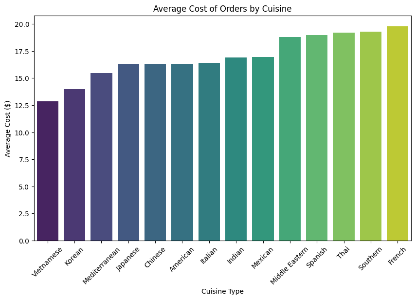

```python
cuisine_cost = (
    df.groupby("cuisine_type")["cost_of_the_order"]
      .mean()
      .sort_values()
)

plt.figure(figsize=(10,6))
sns.barplot(x=cuisine_cost.index, y=cuisine_cost.values, hue=cuisine_cost.index, palette="viridis")

plt.title("Average Cost of Orders by Cuisine")
plt.xlabel("Cuisine Type")
plt.ylabel("Average Cost ($)")
plt.xticks(rotation=45)
plt.show()
```

**Observations:**

1. Vietnamese restaurant orders cost on an average the least which is about $12.5
2. French restaurants cost the most with an average of \$19
3. Japanese, Chinese and American cuisines on an average cost the same

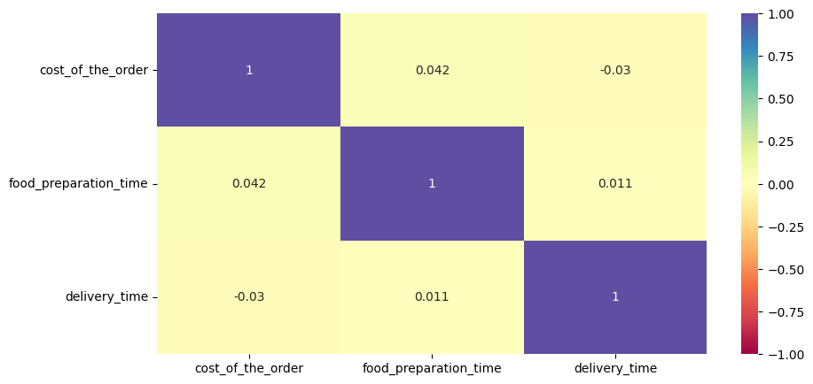

```python
numerical_col = ['cost_of_the_order','food_preparation_time','delivery_time']

plt.figure(figsize=(10,5))
sns.heatmap(df[numerical_col].corr(),annot=True,cmap='Spectral',vmin=-1,vmax=1)
plt.show()
```

**Observations:** 1) Each column has 100% correlation with itself 2) Cost_of_the_order and food_preparation_time has the most positive correlation 3) Delivery_time and cost_of_the_order has negative correlation

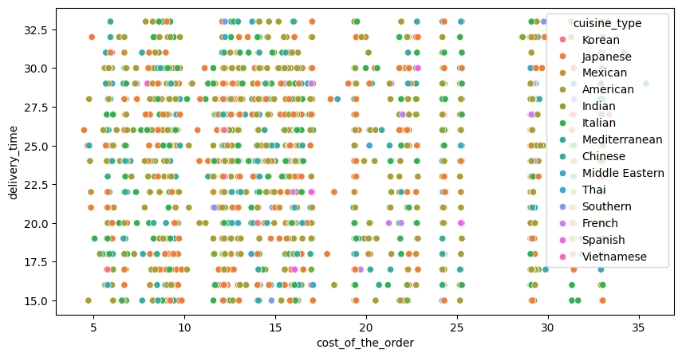

```python
plt.figure(figsize=(10,5))
sns.scatterplot(data=df,x='cost_of_the_order',y='delivery_time',hue='cuisine_type')
plt.show()
```

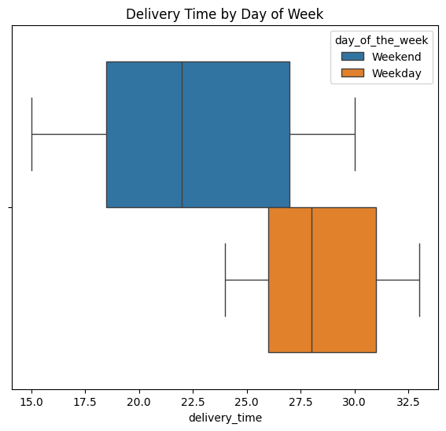

```python
plt.figure(figsize=(7,6))
sns.boxplot(data=df, x="delivery_time", hue="day_of_the_week")
plt.title("Delivery Time by Day of Week")
plt.show()
```

**Observations:**

1. Min delivery time for weekday is 24 mins while for weekend is 15 mins
2. Delivery time is faster during the weekends while slower during the weekdays
3. There are no outliers in this graph

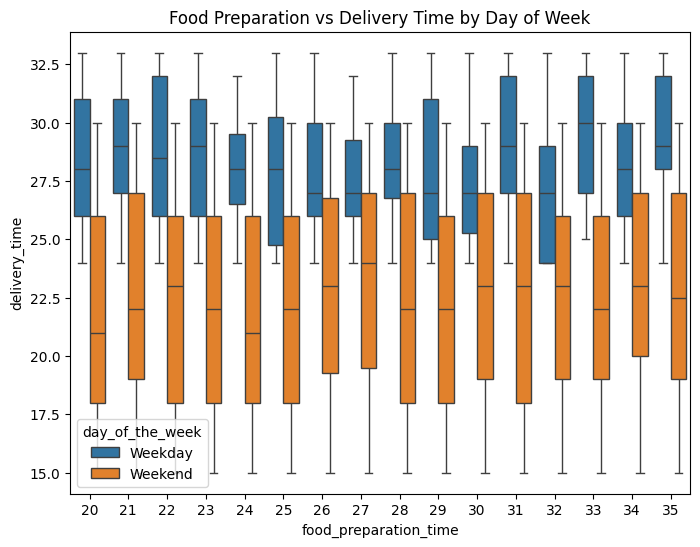

```python
plt.figure(figsize=(8,6))
sns.boxplot(data=df, x="food_preparation_time", y="delivery_time", hue="day_of_the_week")
plt.title("Food Preparation vs Delivery Time by Day of Week")
plt.show()
```

**Observations:**

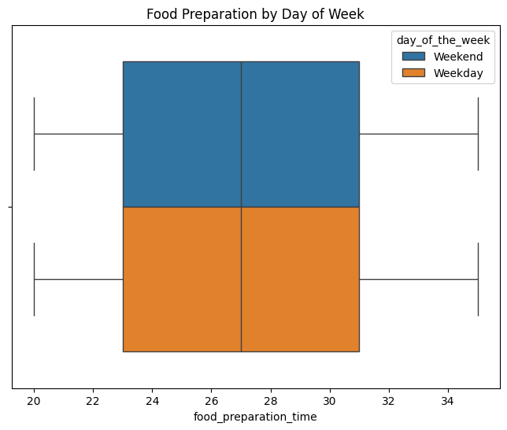

```python
plt.figure(figsize=(8,6))
sns.boxplot(data=df, x="food_preparation_time", hue="day_of_the_week")
plt.title("Food Preparation by Day of Week")
plt.show()
```

**Observations:**

1. Food preparation time is the same during both the weekdays and weekends
2. There are no outliers in this graph

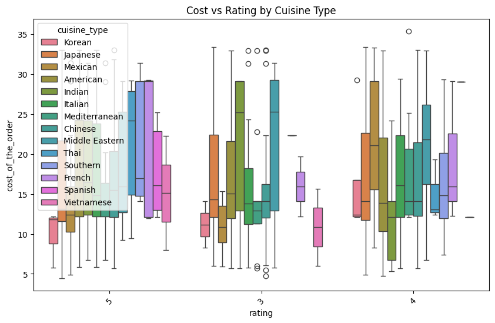

```python
#Cost of the order vs Rating by Cuisine type
plt.figure(figsize=(10,6))
sns.boxplot(x="rating", y="cost_of_the_order", hue="cuisine_type", data=df)
plt.title("Cost vs Rating by Cuisine Type")
plt.xticks(rotation=45)
plt.show()
```

**Observations:**

**Question 13:** The company wants to provide a promotional offer in the advertisement of the restaurants. The condition to get the offer is that the restaurants must have a rating count of more than 50 and the average rating should be greater than 4. Find the restaurants fulfilling the criteria to get the promotional offer. [3 marks]

```python
rating_count = df.groupby('restaurant_name')['rating'].count()
```

```python
df["rating"] = pd.to_numeric(df["rating"])
average_rating = df.groupby('restaurant_name')['rating'].mean()
```

```python
restaurant_stats = pd.DataFrame({
    "rating_count": rating_count,
    "average_rating": average_rating
})

# Step 4: Filter restaurants
promo_restaurants = restaurant_stats[
    (restaurant_stats["rating_count"] > 50) & (restaurant_stats["average_rating"] > 4)
]

# Step 5: Print results
print("Restaurants eligible for promotional offer:")
print(promo_restaurants)
```

```
Restaurants eligible for promotional offer:
                           rating_count  average_rating
restaurant_name
Blue Ribbon Fried Chicken            64        4.328125
Blue Ribbon Sushi                    73        4.219178
Shake Shack                         133        4.278195
The Meatball Shop                    84        4.511905
```

**Observation:**

1. 4 restaurants are eligible for the promotional offer
2. The Meatball Shop has the most average rating while Shake Shack has the most number of rating
3. Blue Ribbon Fried Chicken has the least about of the ratings out of the 4 which is 64

**Question 14:** The company charges the restaurant 25% on the orders having cost greater than 20 dollars and 15% on the orders having cost greater than 5 dollars. Find the net revenue generated by the company across all orders. [3 marks]

```python
revenue = 0
for x in df['cost_of_the_order']:
    if 5.0 < x < 20.0:
        revenue += x * 0.15
    elif x >= 20:
        revenue += x * 0.25

print("Total revenue generated by the company: $",revenue)
```

```
Total revenue generated by the company: $ 6166.302999999994
```

**Observations:** The net revenue generated by the company is more than \$6000

**Question 15:** The company wants to analyze the total time required to deliver the food. What percentage of orders take more than 60 minutes to get delivered from the time the order is placed? (The food has to be prepared and then delivered.) [2 marks]

```python
total_time=df['food_preparation_time']+df['delivery_time']
c=0
count_of_orders=len(df['delivery_time'])
for x in total_time:
  if(x>60):
    c+=1

percentage_of_orders=(c/count_of_orders)*100
print(f"The percentage of orders that take more than 60 mins is {percentage_of_orders:.2f}%")
```

```
The percentage of orders that take more than 60 mins is 10.54%
```

**Observations:**

1. Nearly 90\% of the orders take less than 60 mins to be delivered from the time the order has been placed
2. Only about 10.5\% of the orders take more than 60 mins to reach the customers

**Question 16:** The company wants to analyze the delivery time of the orders on weekdays and weekends. How does the mean delivery time vary during weekdays and weekends? [2 marks]

```python
# Calculate total time = prep + delivery
df["total_time"] = df["food_preparation_time"] + df["delivery_time"]

# Mean delivery time for weekdays
weekday_mean = df[df["day_of_the_week"] == "Weekday"]["total_time"].mean()

# Mean delivery time for weekends
weekend_mean = df[df["day_of_the_week"] == "Weekend"]["total_time"].mean()

print(f"The mean delivery time for weekdays is {weekday_mean:.2f} minutes")
print(f"The mean delivery time for weekends is {weekend_mean:.2f} minutes")
```

```
The mean delivery time for weekdays is 55.55 minutes
The mean delivery time for weekends is 49.91 minutes
```

**Observations:**

**Conclusion and Recommendations**

**Question 17:** What are your conclusions from the analysis? What recommendations would you like to share to help improve the business? (You can use cuisine type and feedback ratings to drive your business recommendations.) [6 marks]

**Conclusions:**

**Recommendations:**

1. Restaurants and delivery partners can club multiple orders from the same or nearby localities into a single trip. This reduces delivery time, fuel costs, and traffic overhead while improving efficiency.
2. Balance quality and affordability: cuisines that are both tasty and reasonably priced attract repeated customers.
3. High-rated restaurants should maintain consistency; low-rated ones should analyze customer reviews for pain points
4. Offer good deals to attract more orders.